# IE360_HW1_Beyza

## 1-Introduction

In the last years, Turkey has experienced rising inflation, house prices and exchange rates and these has become hot topic. Since they affect the daily life in many ways, their behaviour is important for citizens' welfare. Also, according to this exchange rate and inflation behavior, people buy or sell gold to protect the value of their money. Firstly, house prices are important in Turkish economy because it is a common practice to buy a house as an investment. On the other hand, due to the fact that many goods especially electronic devices are imported, they are sensetive to any volatility in exchange rates. Finally, inflation means, in general, change in cost of living. Therefore, it affects life quality and welfare of the people. In this study, I tried to explain the relation among parameters mentioned by investigating the correlation and plotting their trends from the data from 2015 to 2021. The data from January 2015 to December 2021 was taken from "Elektronik Veri Dağıtım Sistemi" (EVDS) as monthly and the search data for key word "altın" was taken from Google Trends data.

*For exchange rate, US Dollar(Buying); for house prices, "Housing Unit Prices for Turkey - TL/sq m" and finally for inflation, "Consumer Price Index (CPI)" data is used. The aim of the study is to answer the following questions:*

- Is unit housing price sensitive to the fluctuations in the exchange rate?
- Does increase in the exchange rate means increase in the cost of living which is inflation?
- Is there really a link between the behavior of inflation and the buying and selling of gold? Could people be buying and selling gold to avoid inflation?
- Could the increase in inflation be associated with the recent increase in house prices?

## 2-Importing Necessary Packages / Preparing data to further analysis

```r
require(GGally)
library(ggplot2)
library(ggfortify)
library(forecast)
library(xts)
library(ggcorrplot)
library(openxlsx)
library(zoo)
library(dplyr)
library(lubridate)
```

```r
adjust<-function(data_path,column_name){
    df_name<-read.xlsx(data_path)
    df_name$Date <-as.Date(as.yearmon(x = df_name$Date))
    colnames(df_name)[2] <- column_name
    return(df_name)
    }

house_prices=adjust("EVDS_housepr.xlsx","house_price")
exchange_rate=adjust("EVDS_exchange.xlsx","exchange_rate")
price_index=adjust("EVDS_cpi.xlsx","price_index")
```

```r
all_data = merge(house_prices,merge(exchange_rate,price_index,by="Date"),by="Date")
str(all_data)
```

```
'data.frame':	84 obs. of  4 variables:
 $ Date         : Date, format: "2015-01-01" "2015-02-01" ...
 $ house_price  : num  1806 1845 1883 1917 1953 ...
 $ exchange_rate: num  2.33 2.46 2.58 2.65 2.65 ...
 $ price_index  : num  250 252 255 259 261 ...
```

```r
data_ts <- xts(x = all_data[,-1], order.by = all_data$Date)
glimpse(data_ts)
```

```
An 'xts' object on 2015-01-01/2021-12-01 containing:
  Data: num [1:84, 1:3] 1806 1845 1883 1917 1953 ...
 - attr(*, "dimnames")=List of 2
  ..$ : NULL
  ..$ : chr [1:3] "house_price" "exchange_rate" "price_index"
  Indexed by objects of class: [Date] TZ: UTC
  xts Attributes:
 NULL
```

## 3.1-Analysis of exchange rate (US Dollar-Buying)

### Plots&visualizations

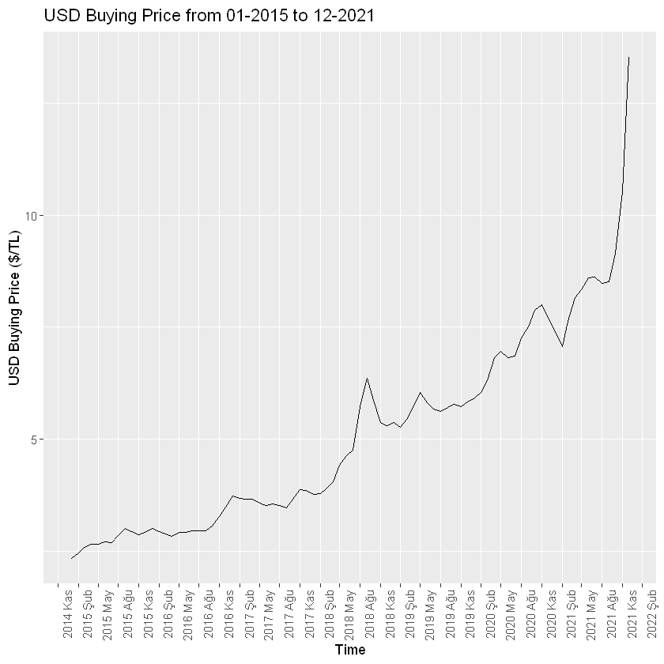

```r
ggplot(exchange_rate,aes(x=Date,y=exchange_rate)) +  geom_line()+
  xlab("Time") + ylab("USD Buying Price ($/TL)")+ ggtitle("USD Buying Price from 01-2015 to 12-2021")+
  scale_x_date(date_breaks = '3 month', date_labels = '%Y %b', date_minor_breaks = '3 month' ) +
  theme(axis.text.x=element_text(angle=90,hjust=1, vjust = 1.4))
```

> Looking at the buying price of the dollar, a general upward trend is seen in the exchange rate. This increase is gaining momentum especially towards the end of 2021. However, no seasonality is observed in this time period

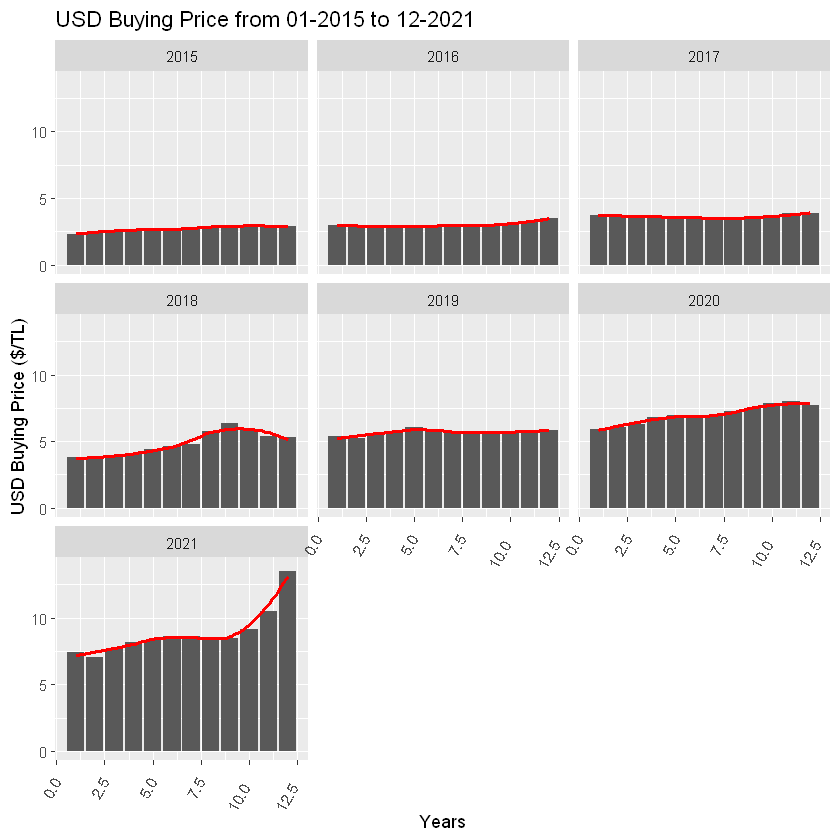

```r
ggplot(exchange_rate,aes(x=month(Date),y=exchange_rate)) + geom_bar(stat='identity') +geom_smooth(color='red',linetype='solid',fill=NA)+ facet_wrap(~year(Date)) +
xlab('Years') + ylab('USD Buying Price ($/TL)') + ggtitle('USD Buying Price from 01-2015 to 12-2021')+theme(axis.text.x=element_text(angle=60, hjust=1.8, vjust = 1.2))
```

> When the dollar purchase price is analyzed from year to year and month to month, even if it increases little by little until 2021 and does not show a significant increase, Turkey has experienced a noticeable increase in the last 2 years.  
> This may be due to covid or various political policies.

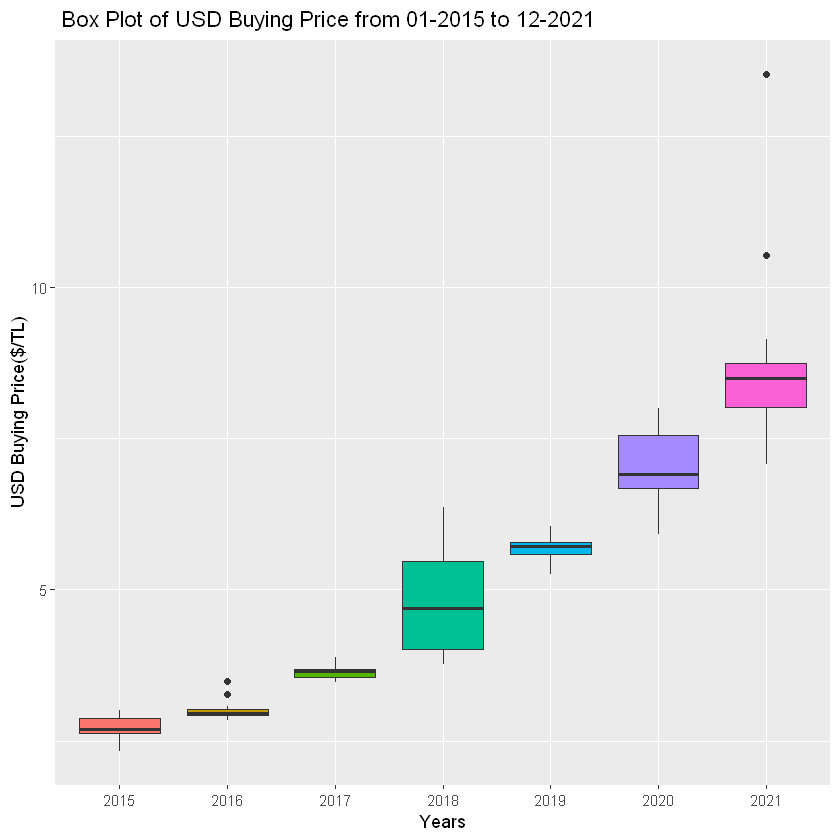

```r
ggplot(exchange_rate,aes(x=factor(year(Date)),y=exchange_rate))+ geom_boxplot(aes(fill=factor(year(Date))))+
  xlab("Years") + ylab("USD Buying Price($/TL)")+ ggtitle(" Box Plot of USD Buying Price from 01-2015 to 12-2021")+
  theme(legend.position = "none")
```

> Another representation, box pilots, shows the deviation of the dollar price from the median value on a yearly basis. The smallness of the box plot in 2016, 2017 and 2019 shows that the variablity in dollar prices is low.  
> In 2021, the fact that the 50 percent quartile is close to the 75 percent quartile indicates an accumulation in the upper values of the prices.

## 3.2- Analysis of Consumer Price Index

### Plots&visualizations

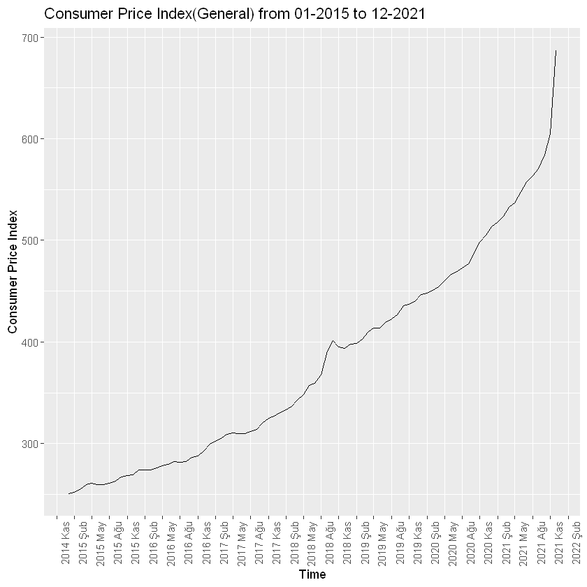

```r
ggplot(price_index,aes(x=Date,y=price_index)) + geom_line(color = 'black') +

    labs(title = 'Consumer Price Index(General) from 01-2015 to 12-2021', x = 'Time', y = 'Consumer Price Index') +
    scale_x_date(date_breaks = '3 month', date_labels = '%Y %b', date_minor_breaks = '3 month' ) +
    theme(axis.text.x=element_text(angle=90,hjust=1, vjust = 1.4))
```

> Looking at the consumer price index, it is seen that the inflation basket is in an upward trend without fluctuating too much. Although it made a small peak between August and November 2018, it continues to increase in its previous momentum.  
> Towards the last months of 2021, it shows an increase close to exponential with a significant increase in acceleration.

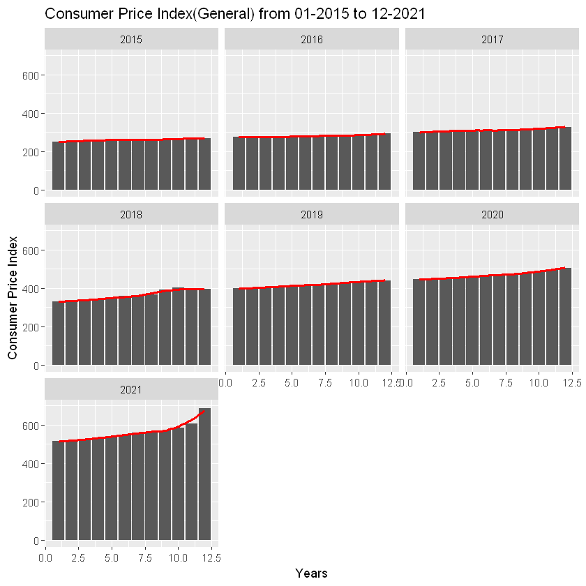

```r
ggplot(price_index,aes(x=month(Date),y=price_index)) + geom_bar(stat='identity') +geom_smooth(color='red',linetype='solid',fill=NA)+ facet_wrap(~year(Date)) +
xlab('Years') + ylab('Consumer Price Index') + ggtitle('Consumer Price Index(General) from 01-2015 to 12-2021')
```

> When the histograms of the data on a monthly basis for each year are examined, this trend is more difficult to understand. however, it is possible to see the overall increase when looking at the level of each year separately.

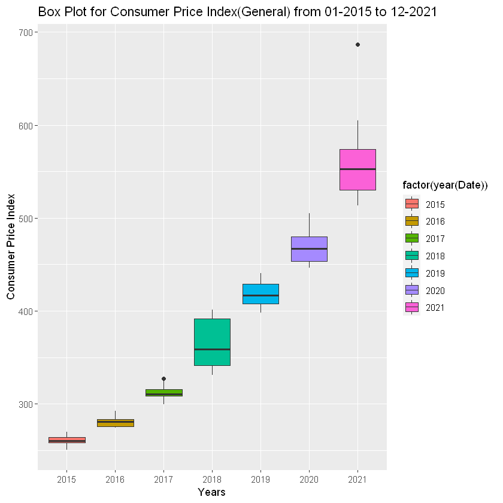

```r
ggplot(price_index,aes(x=factor(year(Date)),y=price_index))+ geom_boxplot(aes(fill=factor(year(Date))))+
  xlab("Years") + ylab('Consumer Price Index')+ ggtitle('Box Plot for Consumer Price Index(General) from 01-2015 to 12-2021')
```

> When the box plots are examined, it is seen that the price levels from 2015 to 2017 do not show much variation on the basis of their years.  
> Especially in 2018, as can be seen from the variance box plot shown by the price index, it is increasing.  
> It is possible to observe the general trend by looking at the level of the box plots.

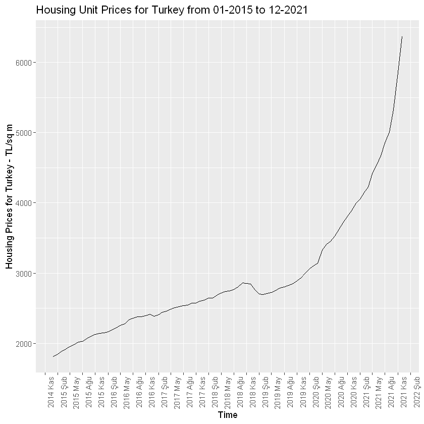

```r
ggplot(house_prices,aes(x=Date,y=house_price)) + geom_line(color = 'black') +

    labs(title = 'Housing Unit Prices for Turkey from 01-2015 to 12-2021', x = 'Time', y = 'Housing Prices for Turkey - TL/sq m') +
    scale_x_date(date_breaks = '3 month', date_labels = '%Y %b', date_minor_breaks = '3 month' ) +
    theme(axis.text.x=element_text(angle=90,hjust=1, vjust = 1.4))
```

> When home unit prices are examined, a different picture emerges. generally rising house prices can be decomposed in two trends. House prices, which showed a linear increase until August 2018, are on a non-linear increase since February 2019.

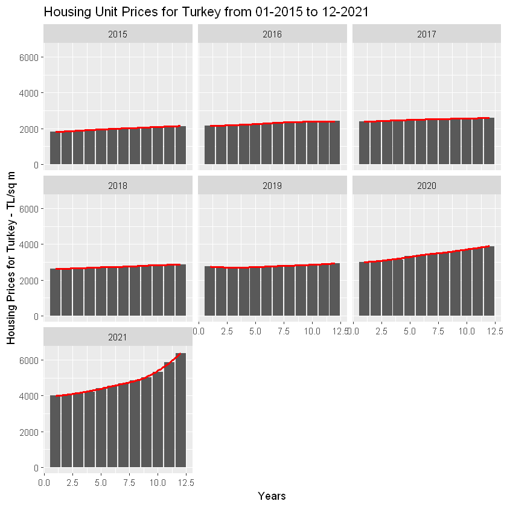

```r
ggplot(house_prices,aes(x=month(Date),y=house_price)) + geom_bar(stat='identity') +geom_smooth(color='red',linetype='solid',fill=NA)+ facet_wrap(~year(Date)) +
xlab('Years') + ylab('Housing Prices for Turkey - TL/sq m') + ggtitle('Housing Unit Prices for Turkey from 01-2015 to 12-2021')
```

> When looking at the histograms for the months of each year, it is more difficult to see where this exponential increase starts, but the acceleration in the end of 2019, especially in the beginning of 2020, can be understood from the smoothed red line.

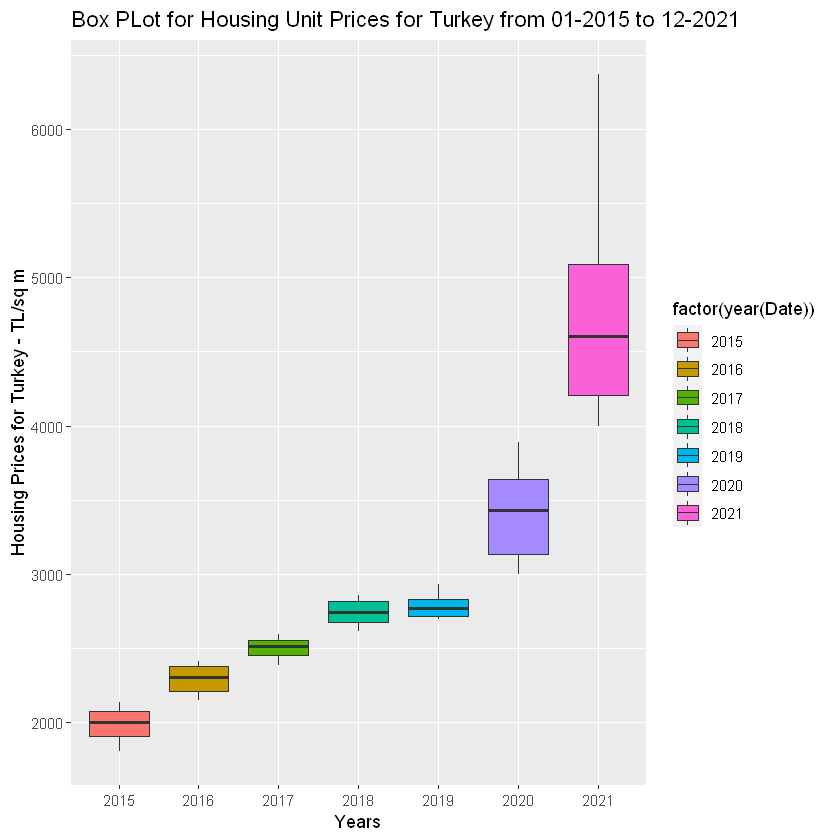

```r
ggplot(house_prices,aes(x=factor(year(Date)),y=house_price))+ geom_boxplot(aes(fill=factor(year(Date))))+
  xlab("Years") + ylab('Housing Prices for Turkey - TL/sq m')+ ggtitle('Box PLot for Housing Unit Prices for Turkey from 01-2015 to 12-2021')
```

> When the levels of the box plots are examined, two trends are clearly observed.

## 3.4- Analysis of the Google search for the key word "altın"

```r
trend_df<-read.csv("gold_trends.csv")
trend_df$Ay <-as.Date(as.yearmon(x = trend_df$Ay))
colnames(trend_df) <-c("Date",'search_index')
```

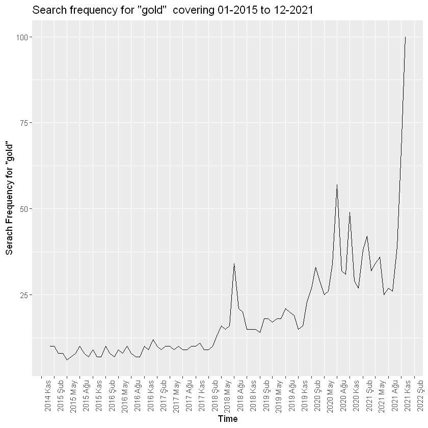

```r
ggplot(trend_df,aes(x=Date,y=search_index)) + geom_line(color = 'black') +

    labs(title = 'Search frequency for "gold"  covering 01-2015 to 12-2021', x = 'Time', y = 'Serach Frequency for "gold"') +
    scale_x_date(date_breaks = '3 month', date_labels = '%Y %b', date_minor_breaks = '3 month' ) +
    theme(axis.text.x=element_text(angle=90,hjust=1, vjust = 1.4))
```

> According to Google Trends data, until February 2018, the search frequency for "gold" fluctuates at the same level rather than showing a trend. after this date, it starts to climb with an increasing trend by showing high and sharp peaks. As of August 2021, it skyrocketed with an unprecedented increase.

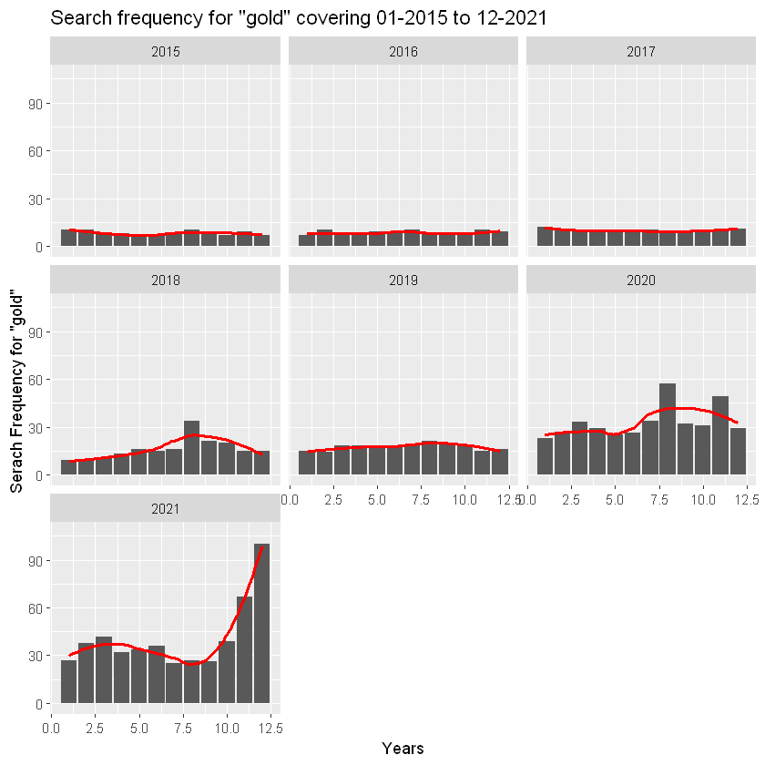

```r
ggplot(trend_df,aes(x=month(Date),y=search_index)) + geom_bar(stat='identity') +geom_smooth(color='red',linetype='solid',fill=NA)+ facet_wrap(~year(Date)) +
xlab('Years') + ylab('Serach Frequency for "gold" ') + ggtitle('Search frequency for "gold" covering 01-2015 to 12-2021')
```

> These fluctuations are clearly observable even on the smoothed line. However, there is no pattern,ie seasonaliy, observed if each year is analyzed one by one.

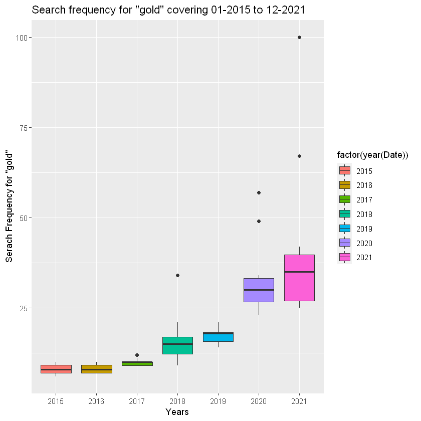

```r
ggplot(trend_df,aes(x=factor(year(Date)),y=search_index))+ geom_boxplot(aes(fill=factor(year(Date))))+
  xlab("Years") + ylab('Serach Frequency for "gold"')+ ggtitle('Search frequency for "gold" covering 01-2015 to 12-2021')
```

> Especially in recent years, the frequency of searching for the gold key word has reached very high levels in some months and created outlier points.

## 4- Pairwise Comparisons

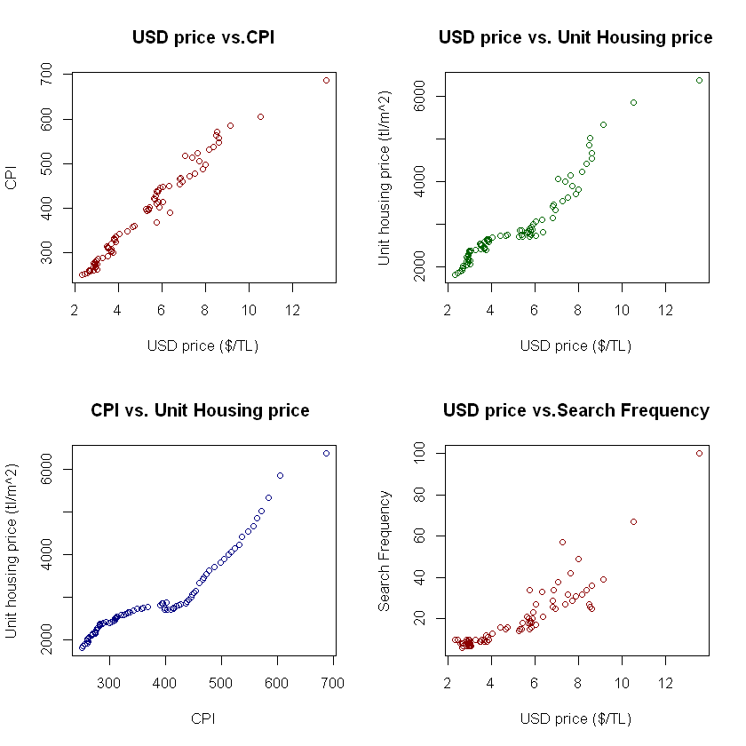

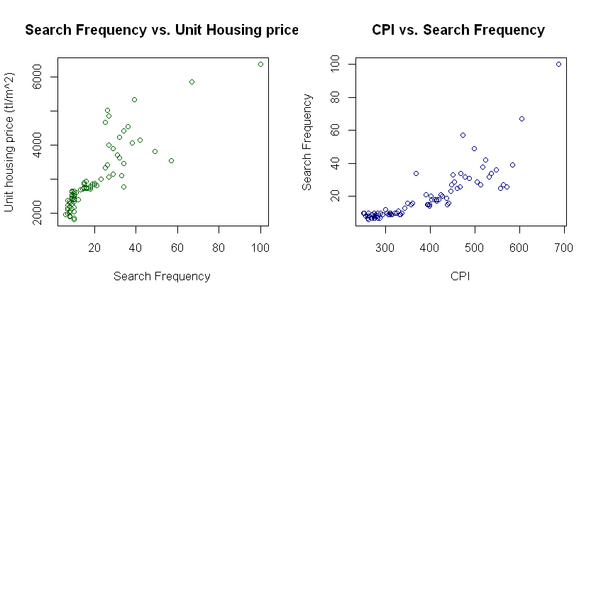

```r
par(mfrow=c(2,2))
plot(x = all_data$exchange_rate,y = all_data$price_index,
     main = "USD price vs.CPI",
     xlab = "USD price ($/TL)", ylab = "CPI", col="darkred")
plot(x = all_data$exchange_rate,y = all_data$house_price,
     main = "USD price vs. Unit Housing price",
     xlab = "USD price ($/TL)", ylab = "Unit housing price (tl/m^2)", col="darkgreen")
plot(x = all_data$price_index,y = all_data$house_price,
     main = "CPI vs. Unit Housing price ",
     xlab = "CPI", ylab = "Unit housing price (tl/m^2)",col = "navyblue")
plot(x = all_data$exchange_rate,y = trend_df$search_index,
     main = "USD price vs.Search Frequency",
     xlab = "USD price ($/TL)", ylab = "Search Frequency", col="darkred")
plot(x = trend_df$search_index,y = all_data$house_price,
     main = "Search Frequency vs. Unit Housing price",
     xlab = "Search Frequency", ylab = "Unit housing price (tl/m^2)", col="darkgreen")
plot(x = all_data$price_index,y = trend_df$search_index,
     main = "CPI vs. Search Frequency ",
     xlab = "CPI", ylab = "Search Frequency",col = "navyblue")
```

When each data is compared in pairs, it is clear that there is a positive correlation between each of these variables, although some have an almost linear relationship and some have a non-linear relationship. Although it is not correct to make a comment about causation here, these 3 parameters and the interest in the price of gold (Here, Google search for the key word "gold" is associated with the demand for gold) are moving together ,generally.My reasoning and inferences for these relations are below:

- There is two-sided relation between inflation and exchange rates. On one hand, inflation decreases the purchasing power, which results in decrease in the value of money against other currencies. As a result, exchange rate increases with the increase of inflation. On the other hand, Turkey uses most of the imported goods as a intermediary in production. When the cost of importing intermediary goods increases, the cost of final products also increases consequently. This cost increase is reflected in prices, which brings about inflation.
- Looking at the relationship between exchange rate and house prices, when exchange rates increases, the house price becomes relatively cheaper to the foreigners. This boosts the demand for houses, as a result, house price increases. In addition, with the increase in this exchange rate and depreciation of the currency, the law of granting citizenship to citizens who bought a house for 250 thousand dollars, which was recently enacted has also been a factor in the increase in prices by increasing the demand for house prices significantly.
- Like home investment, people turn to gold to protect themselves from inflation and the rise of the exchange rate. Therefore, an increase in either of these will increase the demand for gold, thus increasing the price. It is possible that the frequency of Google searches for "gold" will increase with the increase in demand.

## 5- Overall Picture

- ### Normalization for visualization of 3 parameters to see the correlation  
  To see the three parameters on the same graph and compare their behavior, they are scaled to be between 0 and 1.

```r
normalize<-function(data_frame){
    col<-colnames(data_frame)
    dummy<-data_frame
    for (i in 1:3){
        dummy[,col[i]]=(dummy[,col[i]]-min(dummy[,col[i]]))/(max(dummy[,col[i]])-min(dummy[,col[i]]))

    }
    return (dummy)
}
```

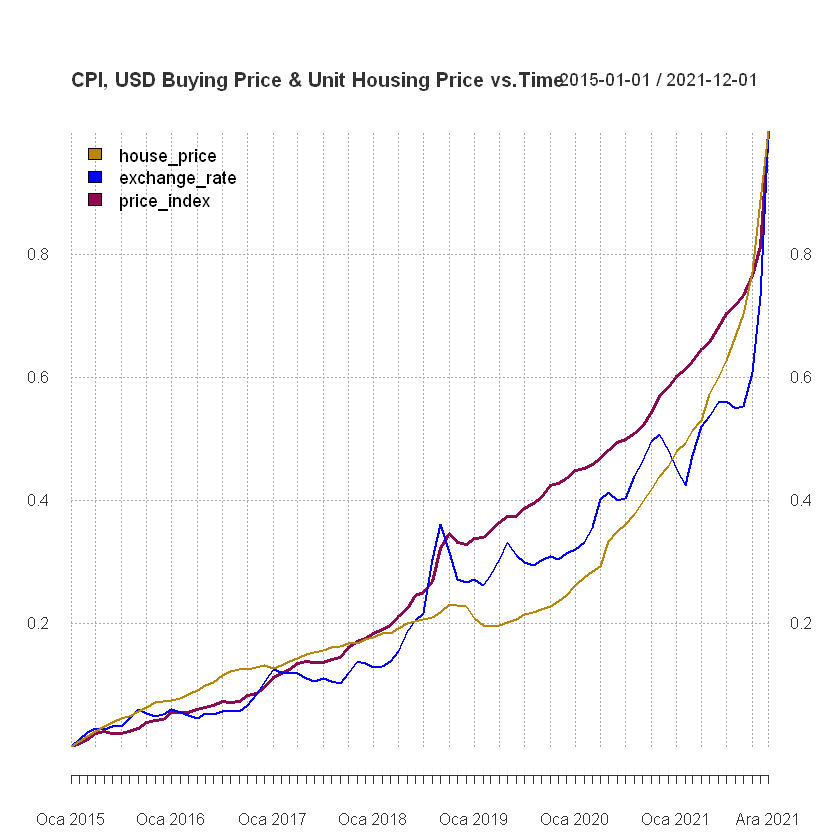

```r
colors = c("darkgoldenrod","blue","deeppink4")
plot(x = normalize(data_ts),ylab = "Rate ", main = "CPI, USD Buying Price & Unit Housing Price vs.Time",
     col = colors, lwd = c(2,2,3),legend.loc = "topleft", minor.ticks = "months",
     grid.ticks.on = "quarter", grid.ticks.lty = "dotted")
```

> When the behavior of these 3 parameters is examined, it is seen that all of them have been increasing continuously in these 7 years with different small fluctuations. At the end of 2018, 2019, there is a peak in all different scales. After this point, their rate of increase increases even more and they increase with a great speed at the end of 2021.

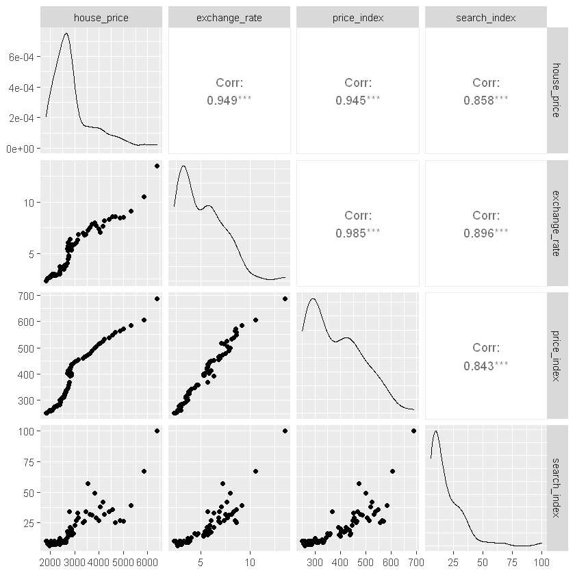

```r
merged=merge(all_data,trend_df,by="Date")
ggpairs(merged[,c(2:5)])
```

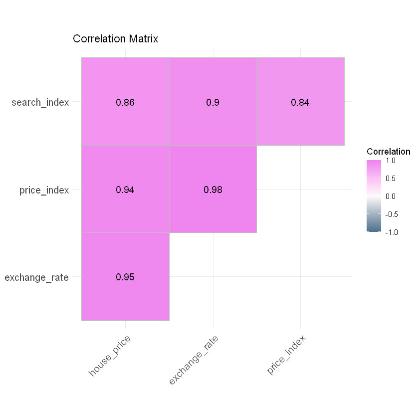

```r
ggcorrplot(corr = cor(merged[,c(2:5)]),


           type = "upper", lab = TRUE,
           title = "Correlation Matrix",
           colors = c("skyblue4","snow","violet"),
           legend.title = "Correlation",)
```

## 6- Conclusion

- *Is unit housing price sensitive to the fluctuations in the exchange rate?*  
  It seems that there is a great correlation between buying prices in USD and house prices. Therefore, house prices may be sensitive to exchange rate and prices may be in line with exchange rate fluctuations.
- *Does increase in the exchange rate means increase in the cost of living which is inflation?*  
  The fact that the usd buying price is correlated with the consumer price index of 0.98 probably means that when one increases, the other increases.
- *Is there really a link between the behavior of inflation and the buying and selling of gold? Could people be buying and selling gold to avoid inflation?*  
  Looking to the 0.84 correlation, it can be said that there is a strong linear relationship between inflation and search frequency. When inflation rises, people's willingness to invest in lats and save their money may partly explain the increase in call frequency.
- *Could the increase in inflation be associated with the recent increase in house prices?*  
  Although a causation relationship between these two cannot be determined by looking at the correlation data alone, it is obvious that the increase of these two is parallel. Although house prices are not included in an inflation package, it is observed that inflation increases when house prices increase.

## 7- References

- The data containing three parameters is taken from [EVDS](https://evds2.tcmb.gov.tr/index.php?/evds/serieMarket)
- The data of search frequency for "altın" is taken from [Google Trends](https://trends.google.com/trends/?geo=TR)